# 8 Practical Machine Learning Project

cfmor

29/10/2021

## Course Project

This document includes all the steps done in the 8th course project for the coursera’s Data Science Specialization. Therefore, a brief description of the task, the used data, the procedure, and the obtained results are shown.

### Goal

The goal of this project is to predict the manner in which the subjects did the exercise. This is the “classe” variable in the training set. It may be used any of the other variables to predict with. It should be created a report describing how the model was built, how cross validation was used, what is thought to be the expected out of sample error, and why the choices were made. The prediction model will be used to predict 20 different test cases.

### Background

Using devices such as *Jawbone Up*, *Nike FuelBand*, and *Fitbit* it is now possible to collect a large amount of data about personal activity relatively inexpensively. These type of devices are part of the quantified self movement – a group of enthusiasts who take measurements about themselves regularly to improve their health, to find patterns in their behavior, or because they are tech geeks. One thing that people regularly do is quantify how *much* of a particular activity they do, but they rarely quantify *how well they do it*. In this project, your goal will be to use data from accelerometers on the belt, forearm, arm, and dumbell of 6 participants. They were asked to perform barbell lifts correctly and incorrectly in 5 different ways. More information is available from the website here:http://web.archive.org/web/20161224072740/http:/groupware.les.inf.puc-rio.br/har (see the section on the Weight Lifting Exercise Dataset).

### Data

The data used in this project is sourced from the following sites.

The training data for this project are available here: https://d396qusza40orc.cloudfront.net/predmachlearn/pml-training.csv

The test data are available here: https://d396qusza40orc.cloudfront.net/predmachlearn/pml-testing.csv

The data for this project come from this source: http://web.archive.org/web/20161224072740/http:/groupware.les.inf.puc-rio.br/har. If you use the document you create for this class for any purpose please cite them as they have been very generous in allowing their data to be used for this kind of assignment.

## Retrieving and cleaning the data.

This section contains the procedure applied to the raw data in order to get the dataset to be used in the machine learning model.

```r
# Load packages.
library(data.table)
library(naniar)
library(tidyr)
library(dplyr)
```

```r
# Retrieve train and test sets.
trainset <- data.table::fread("https://d396qusza40orc.cloudfront.net/predmachlearn/pml-training.csv")
testset <- data.table::fread("https://d396qusza40orc.cloudfront.net/predmachlearn/pml-testing.csv")

# Visualize data (train).
summary(trainset)
```

[output not shown]

[output cut: 289 more lines]

[output not shown]

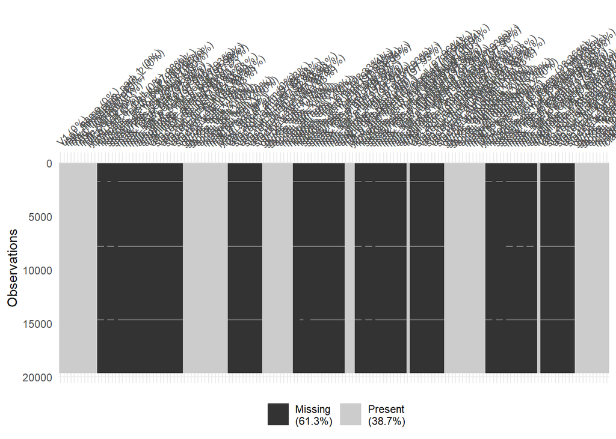

```r
# Checking missing data estimate.
vis_miss(trainset, warn_large_data=FALSE)
```

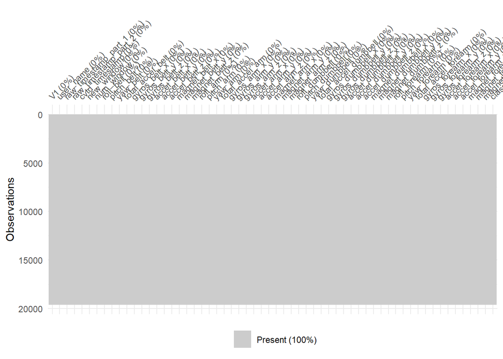

```r
# It is seen that there are many columns with almost only NA values, these are dropped.
trainset <- trainset %>%
                select_if(~ !any(is.na(.)))
vis_miss(trainset, warn_large_data=FALSE)
```

```r
# Variables like timestamp, subject and id are not require, since they don't give valuable information or they will cause overfitting.
trainset <- select(trainset, -c(names(trainset)[1:7]))
# Turn the classe into numerical value.
# trainset$classe <- match(trainset$classe, c(unique(trainset$classe)))
```

## Machine learning model.

```r
library(caret)
set.seed(33)
# Split the data into train and test sets.
inTrain = createDataPartition(trainset$classe, p=0.75, list=FALSE)
traintrain = trainset[ inTrain,]
traintest = trainset[-inTrain,]
```

### Training phase.

```r
# Training different models: random forest classifier, classification tree, linear discriminant analysis classifier.
modRF <- train(classe ~.,
               data=traintrain,
               method="rf",
               preProcess=c("pca"),
               trControl=trainControl(method="cv", number=5))

modCT <- train(classe ~.,
               data=traintrain,
               method="rpart",
               preProcess=c("pca"),
               trControl=trainControl(method="cv", number=5))

modLDA <- train(classe ~.,
                data=traintrain,
                method="lda",
                preProcess=c("pca"),
                trControl=trainControl(method="cv", number=5))
```

### Testing phase.

```r
## Random forest classifier.
# Get predictions.
testRF <- predict(modRF, traintest)
# Evaluate the results.
print(cmRF <- confusionMatrix(table(traintest$classe, testRF)))
```

```
## Confusion Matrix and Statistics
##
##    testRF
##        A    B    C    D    E
##   A 1384    7    3    0    1
##   B   13  920   15    1    0
##   C    1   11  835    6    2
##   D    2    1   41  759    1
##   E    0    6    5    2  888
##
## Overall Statistics
##
##                Accuracy : 0.9759
##                  95% CI : (0.9713, 0.98)
##     No Information Rate : 0.2855
##     P-Value [Acc > NIR] : < 2.2e-16
##
##                   Kappa : 0.9696
##
##  Mcnemar's Test P-Value : 1.628e-05
##
## Statistics by Class:
##
##                      Class: A Class: B Class: C Class: D Class: E
## Sensitivity            0.9886   0.9735   0.9288   0.9883   0.9955
## Specificity            0.9969   0.9927   0.9950   0.9891   0.9968
## Pos Pred Value         0.9921   0.9694   0.9766   0.9440   0.9856
## Neg Pred Value         0.9954   0.9937   0.9842   0.9978   0.9990
## Prevalence             0.2855   0.1927   0.1833   0.1566   0.1819
## Detection Rate         0.2822   0.1876   0.1703   0.1548   0.1811
## Detection Prevalence   0.2845   0.1935   0.1743   0.1639   0.1837
## Balanced Accuracy      0.9927   0.9831   0.9619   0.9887   0.9961
```

```r
print(accuracyRF <- cmRF$overall[1])
```

```
## Accuracy
## 0.975938
```

```r
## Classification tree.
# Get predictions.
testCT <- predict(modCT, traintest)
# Evaluate the results.
print(cmCT <- confusionMatrix(table(traintest$classe, testCT)))
```

```
## Confusion Matrix and Statistics
##
##    testCT
##        A    B    C    D    E
##   A 1388    0    0    0    7
##   B  898    0    0    0   51
##   C  842    0    0    0   13
##   D  741    0    0    0   63
##   E  645    0    0    0  256
##
## Overall Statistics
##
##                Accuracy : 0.3352
##                  95% CI : (0.322, 0.3486)
##     No Information Rate : 0.9205
##     P-Value [Acc > NIR] : 1
##
##                   Kappa : 0.0812
##
##  Mcnemar's Test P-Value : NA
##
## Statistics by Class:
##
##                      Class: A Class: B Class: C Class: D Class: E
## Sensitivity            0.3075       NA       NA       NA  0.65641
## Specificity            0.9821   0.8065   0.8257   0.8361  0.85711
## Pos Pred Value         0.9950       NA       NA       NA  0.28413
## Neg Pred Value         0.1091       NA       NA       NA  0.96653
## Prevalence             0.9205   0.0000   0.0000   0.0000  0.07953
## Detection Rate         0.2830   0.0000   0.0000   0.0000  0.05220
## Detection Prevalence   0.2845   0.1935   0.1743   0.1639  0.18373
## Balanced Accuracy      0.6448       NA       NA       NA  0.75676
```

```r
print(accuracyCT <- cmCT$overall[1])
```

```
##  Accuracy
## 0.3352365
```

```r
## Linear discriminant analysis classifier.
# Get predictions.
testLDA <- predict(modLDA, traintest)
# Evaluate the results.
print(cmLDA <- confusionMatrix(table(traintest$classe, testLDA)))
```

```
## Confusion Matrix and Statistics
##
##    testLDA
##       A   B   C   D   E
##   A 893 136 163 184  19
##   B 192 421 179  86  71
##   C 201  86 478  50  40
##   D  60 140 121 390  93
##   E  83 190 118 114 396
##
## Overall Statistics
##
##                Accuracy : 0.5257
##                  95% CI : (0.5116, 0.5398)
##     No Information Rate : 0.2914
##     P-Value [Acc > NIR] : < 2.2e-16
##
##                   Kappa : 0.3999
##
##  Mcnemar's Test P-Value : < 2.2e-16
##
## Statistics by Class:
##
##                      Class: A Class: B Class: C Class: D Class: E
## Sensitivity            0.6249  0.43268  0.45137  0.47330  0.63974
## Specificity            0.8555  0.86568  0.90195  0.89853  0.88215
## Pos Pred Value         0.6401  0.44362  0.55906  0.48507  0.43951
## Neg Pred Value         0.8472  0.86043  0.85651  0.89415  0.94429
## Prevalence             0.2914  0.19841  0.21595  0.16803  0.12622
## Detection Rate         0.1821  0.08585  0.09747  0.07953  0.08075
## Detection Prevalence   0.2845  0.19352  0.17435  0.16395  0.18373
## Balanced Accuracy      0.7402  0.64918  0.67666  0.68592  0.76094
```

```r
print(accuracyLDA <- cmLDA$overall[1])
```

```
##  Accuracy
## 0.5256933
```

### Predicting phase.

```r
# Subset same columns as in training.
testset <- testset %>%
                select_if(~ !any(is.na(.))) %>%
                select(-c(names(testset)[1:7]))

# Get predictions with best model (random forest classifier).
print(predictions <- predict(modRF, testset))
```

```
##  [1] B A B A A E D B A A B C B A E E A B B B
## Levels: A B C D E
```

## Results.

After testing the following models:random forest classifier, classification tree, linear discriminant analysis classifier; as the random forest classifier had the best overall accuracy (0.98) it was chosen to make the predictions of the new (unknown) *classes*. The following predictions were obtained:

It must be noted however, that the used classifier used considerably more time to be trained than the other two verified models.